# Test2 - Survival Prediction Model

### Checking for Outliers

```
##
## Call:
## lm(formula = Y ~ X1 + X2 + X3 + X4 + X5 + X6 + X7 + X8 + X9,
##     data = BLOOD[-c(5), ])
##
## Residuals:
##     Min      1Q  Median      3Q     Max
## -251.53  -96.47    3.17   89.66  429.42
##
## Coefficients:
##              Estimate Std. Error t value Pr(>|t|)
## (Intercept) -977.9332   208.4420  -4.692 2.76e-05 ***
## X1            47.6265    19.4761   2.445 0.018640 *
## X2             8.6045     1.5205   5.659 1.14e-06 ***
## X3             8.1149     1.4675   5.530 1.76e-06 ***
## X4            51.5911    36.1226   1.428 0.160452
## X5             0.3586     6.6943   0.054 0.957524
## X6            -0.7038     6.3699  -0.110 0.912530
## X7            59.3557    46.1679   1.286 0.205447
## X8             5.4013    50.3531   0.107 0.915075
## X9           249.0801    67.1583   3.709 0.000592 ***
## ---
## Signif. codes:  0 '***' 0.001 '**' 0.01 '*' 0.05 '.' 0.1 ' ' 1
##
## Residual standard error: 156.1 on 43 degrees of freedom
## Multiple R-squared:  0.8138, Adjusted R-squared:  0.7748
## F-statistic: 20.88 on 9 and 43 DF,  p-value: 5.717e-13
```

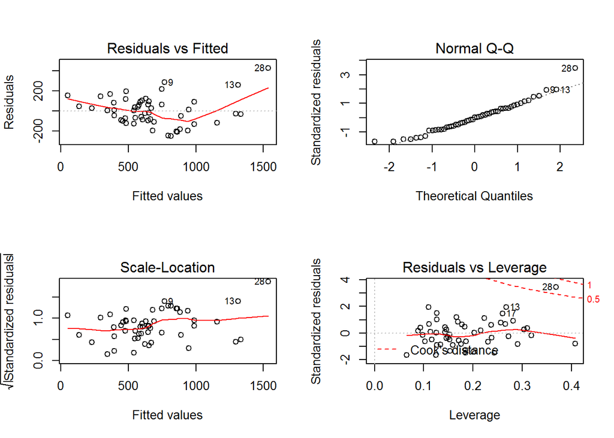

With the removal of the largest outlier we see a great improvement in the fit statistics of the model before the predictor variables have even been screened.

### Checking for Multicollinearity

With all of the variables included in this initial model it is important to check for multicollinearity. Using the package ‘corrplot’ we are able to create a graphical correlation matrix to visually identify highly correlated pairs of predictor variables.

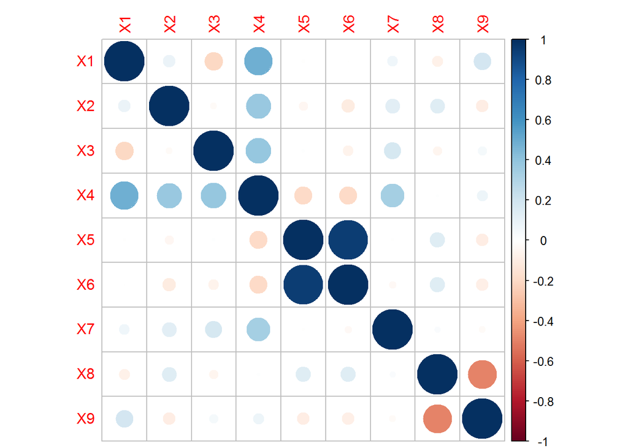

As we would expect the variables X5: Age and X6: Years employed are very highly correlated. The variable X4 is also considerably correlated to X1, X2 and X3. Removing the two variables X6 and X4 we get a new model:

```
##
## Call:
## lm(formula = Y ~ X1 + X2 + X3 + X5 + X7 + X8 + X9, data = BLOOD)
##
## Residuals:
##     Min      1Q  Median      3Q     Max
## -261.94  -97.66  -12.09   97.58  448.34
##
## Coefficients:
##              Estimate Std. Error t value Pr(>|t|)
## (Intercept) -1055.190    181.120  -5.826 5.66e-07 ***
## X1             66.447     14.330   4.637 3.05e-05 ***
## X2              9.597      1.302   7.374 2.85e-09 ***
## X3              9.404      1.092   8.613 4.50e-11 ***
## X5             -1.247      1.962  -0.636 0.528237
## X7             77.679     44.356   1.751 0.086715 .
## X8             10.071     50.297   0.200 0.842210
## X9            246.521     67.206   3.668 0.000644 ***
## ---
## Signif. codes:  0 '***' 0.001 '**' 0.01 '*' 0.05 '.' 0.1 ' ' 1
##
## Residual standard error: 156.3 on 45 degrees of freedom
## Multiple R-squared:  0.8046, Adjusted R-squared:  0.7742
## F-statistic: 26.47 on 7 and 45 DF,  p-value: 5.773e-14
```

### Stepwise Regression

```
##
## Call:
## lm(formula = Y ~ X4 + X3 + X2 + X9 + X1 + X7, data = BLOOD)
##
## Residuals:
##     Min      1Q  Median      3Q     Max
## -250.34  -95.61    2.27   89.09  428.10
##
## Coefficients:
##             Estimate Std. Error t value Pr(>|t|)
## (Intercept) -979.280    165.624  -5.913 3.91e-07 ***
## X4            52.388     32.114   1.631   0.1097
## X3             8.118      1.310   6.195 1.48e-07 ***
## X2             8.644      1.398   6.182 1.54e-07 ***
## X9           246.640     56.867   4.337 7.81e-05 ***
## X1            47.316     18.075   2.618   0.0119 *
## X7            59.222     44.349   1.335   0.1883
## ---
## Signif. codes:  0 '***' 0.001 '**' 0.01 '*' 0.05 '.' 0.1 ' ' 1
##
## Residual standard error: 151 on 46 degrees of freedom
## Multiple R-squared:  0.8135, Adjusted R-squared:  0.7892
## F-statistic: 33.45 on 6 and 46 DF,  p-value: 3.383e-15
```

This model has a higher adjusted R-squared value than the previous model and does show good fit.